# Predictive Analytics On Data To Predict Who Is Performing Excercise Based On Data Of Excercise Activity

Soham Lawar

28 May 2017

## Problem Statement

Using devices such as **Jawbone Up**, **Nike FuelBand**, and **Fitbit** it is now possible to collect a large amount of data about personal activity relatively inexpensively. These type of devices are part of the quantified self movement – a group of enthusiasts who take measurements about themselves regularly to improve their health, to find patterns in their behavior, or because they are tech geeks. One thing that people regularly do is quantify how much of a particular activity they do, but they rarely quantify how well they do it. In this project, your goal will be to use data from accelerometers on the belt, forearm, arm, and dumbell of 6 participants. They were asked to perform barbell lifts correctly and incorrectly in 5 different ways. More information is available from the website here:http://groupware.les.inf.puc-rio.br/har.

## Downloading And Loading Data

```r
if(!file.exists("pml-training.csv")){download.file("https://d396qusza40orc.cloudfront.net/predmachlearn/pml-training.csv", destfile = "pml-training.csv")}

if(!file.exists("pml-testing.csv")){download.file("https://d396qusza40orc.cloudfront.net/predmachlearn/pml-testing.csv", destfile = "pml-testing.csv")}


#Read the training data and replace empty values by NA
trainingDataSet<- read.csv("pml-training.csv", sep=",", header=TRUE, na.strings = c("NA","",'#DIV/0!'))
testingDataSet<- read.csv("pml-testing.csv", sep=",", header=TRUE, na.strings = c("NA","",'#DIV/0!'))
dim(trainingDataSet)
```

```
## [1] 19622   160
```

## Data Preprocessing

Columns having NA values are not considered for analysis.

```r
trainingDataSet <- trainingDataSet[,(colSums(is.na(trainingDataSet)) == 0)]
dim(trainingDataSet)
```

```
## [1] 19622    60
```

```r
testingDataSet <- testingDataSet[,(colSums(is.na(testingDataSet)) == 0)]
dim(testingDataSet)
```

```
## [1] 20 60
```

Columns containing numerical values in training and testing data set are normalized.

```r
numericalsIdx <- which(lapply(trainingDataSet, class) %in% "numeric")

library(caret)
preprocessModel <-preProcess(trainingDataSet[,numericalsIdx],method=c('knnImpute', 'center', 'scale'))
pre_trainingDataSet <- predict(preprocessModel, trainingDataSet[,numericalsIdx])
pre_trainingDataSet$classe <- trainingDataSet$classe
pre_testingDataSet <-predict(preprocessModel,testingDataSet[,numericalsIdx])
```

Columns having near zero variance are deleted.

```r
library(caret)
nzv <- nearZeroVar(pre_trainingDataSet,saveMetrics=TRUE)
pre_trainingDataSet <- pre_trainingDataSet[,nzv$nzv==FALSE]

nzv <- nearZeroVar(pre_testingDataSet,saveMetrics=TRUE)
pre_testingDataSet <- pre_testingDataSet[,nzv$nzv==FALSE]
```

Validation data set is created for testing accuracy of the model.

```r
set.seed(1234)
idxTrain<- createDataPartition(pre_trainingDataSet$classe, p=3/4, list=FALSE)
training<- pre_trainingDataSet[idxTrain, ]
validation <- pre_trainingDataSet[-idxTrain, ]
dim(training)
```

```
## [1] 14718    28
```

```r
dim(validation)
```

```
## [1] 4904   28
```

## Model Building

1. Decision Tree Model

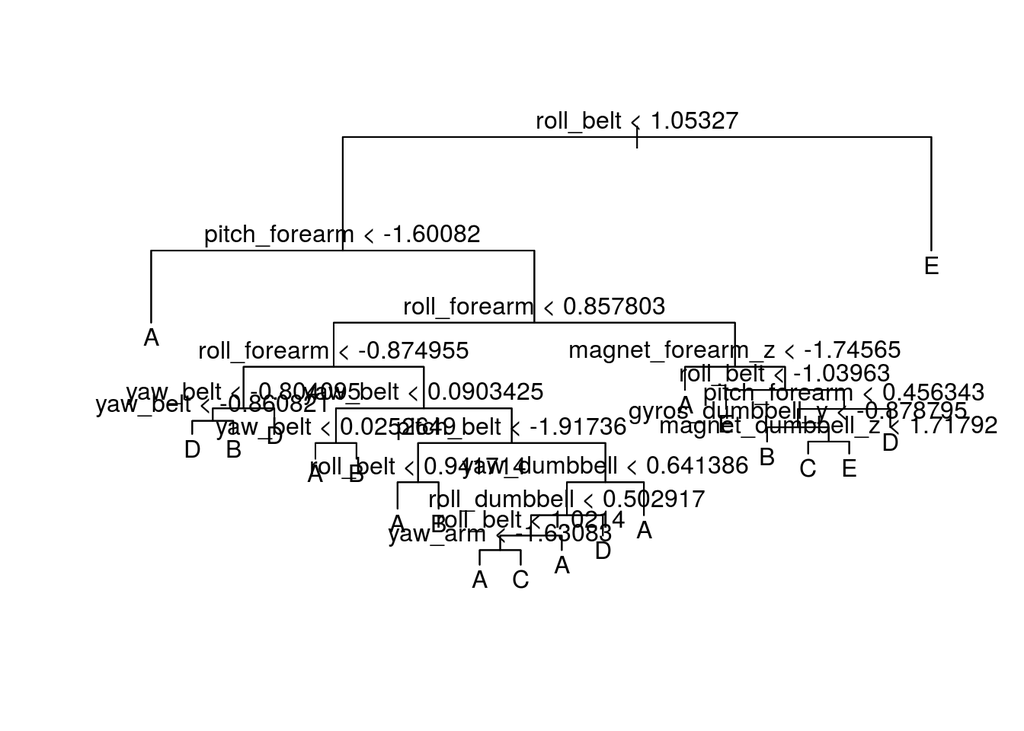

```r
library(tree)

tree <- tree(classe~.,training)
plot(tree)
text(tree,pretty = 0)
```

```r
tree.pred <- predict(tree,validation,type = "class")

confus <- confusionMatrix(validation$classe, tree.pred)
confus
```

```
## Confusion Matrix and Statistics
##
##           Reference
## Prediction    A    B    C    D    E
##          A 1142  133   10   99   11
##          B  102  611   97  121   18
##          C    6  117  579  148    5
##          D   12   40  107  604   41
##          E   19  107   70  150  555
##
## Overall Statistics
##
##                Accuracy : 0.7119
##                  95% CI : (0.699, 0.7245)
##     No Information Rate : 0.2612
##     P-Value [Acc > NIR] : < 2.2e-16
##
##                   Kappa : 0.6372
##  Mcnemar's Test P-Value : < 2.2e-16
##
## Statistics by Class:
##
##                      Class: A Class: B Class: C Class: D Class: E
## Sensitivity            0.8915   0.6062   0.6709   0.5383   0.8810
## Specificity            0.9302   0.9132   0.9317   0.9471   0.9190
## Pos Pred Value         0.8186   0.6438   0.6772   0.7512   0.6160
## Neg Pred Value         0.9604   0.8996   0.9299   0.8737   0.9813
## Prevalence             0.2612   0.2055   0.1760   0.2288   0.1285
## Detection Rate         0.2329   0.1246   0.1181   0.1232   0.1132
## Detection Prevalence   0.2845   0.1935   0.1743   0.1639   0.1837
## Balanced Accuracy      0.9108   0.7597   0.8013   0.7427   0.9000
```

Accuracy for decision tree model is low.

```r
cv.tree <- cv.tree(tree,FUN = prune.misclass)
cv.tree
```

```
## $size
##  [1] 20 19 18 17 16 15 11  5  4  2  1
##
## $dev
##  [1]  4345  4504  4885  4918  4949  5113  6045  7868  8298  9325 10533
##
## $k
##  [1]   -Inf  108.0  145.0  149.0  159.0  192.0  259.0  302.0  434.0  513.5
## [11] 1215.0
##
## $method
## [1] "misclass"
##
## attr(,"class")
## [1] "prune"         "tree.sequence"
```

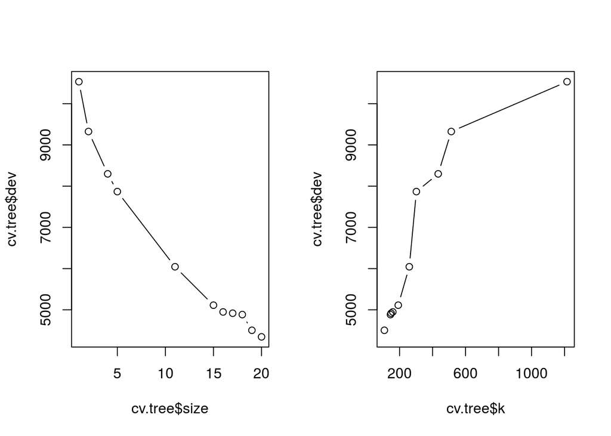

```r
par(mfrow=c(1,2))
plot(cv.tree$size,cv.tree$dev,type = "b")
plot(cv.tree$k,cv.tree$dev, type = "b")
```

3. Bagging

Bagging is a special case of random forest in which all the variables are considered as a predictors for building all decision trees.

```r
library(randomForest)
set.seed(1)
bagging <- randomForest(classe~.,training,mtry = 28,importance=TRUE)
bagging
```

```
##
## Call:
##  randomForest(formula = classe ~ ., data = training, mtry = 28,      importance = TRUE)
##                Type of random forest: classification
##                      Number of trees: 500
## No. of variables tried at each split: 27
##
##         OOB estimate of  error rate: 0.79%
## Confusion matrix:
##      A    B    C    D    E class.error
## A 4168   14    0    0    3 0.004062127
## B   19 2820    7    2    0 0.009831461
## C    0   13 2537   17    0 0.011686794
## D    0    3   13 2393    3 0.007877280
## E    0    9    5    8 2684 0.008130081
```

```r
bag.pred <- predict(bagging,validation,type = "class")

confus <- confusionMatrix(validation$classe, bag.pred)
confus
```

```
## Confusion Matrix and Statistics
##
##           Reference
## Prediction    A    B    C    D    E
##          A 1392    1    0    1    1
##          B    1  944    4    0    0
##          C    0   11  833    9    2
##          D    0    0    7  796    1
##          E    0    4    3    2  892
##
## Overall Statistics
##
##                Accuracy : 0.9904
##                  95% CI : (0.9873, 0.9929)
##     No Information Rate : 0.2841
##     P-Value [Acc > NIR] : < 2.2e-16
##
##                   Kappa : 0.9879
##  Mcnemar's Test P-Value : NA
##
## Statistics by Class:
##
##                      Class: A Class: B Class: C Class: D Class: E
## Sensitivity            0.9993   0.9833   0.9835   0.9851   0.9955
## Specificity            0.9991   0.9987   0.9946   0.9980   0.9978
## Pos Pred Value         0.9978   0.9947   0.9743   0.9900   0.9900
## Neg Pred Value         0.9997   0.9960   0.9965   0.9971   0.9990
## Prevalence             0.2841   0.1958   0.1727   0.1648   0.1827
## Detection Rate         0.2838   0.1925   0.1699   0.1623   0.1819
## Detection Prevalence   0.2845   0.1935   0.1743   0.1639   0.1837
## Balanced Accuracy      0.9992   0.9910   0.9890   0.9916   0.9966
```

Bagging has improved accuracy.

4. Random Forest(Number of predictors = 0.5 * number of variables)

```r
rf <- randomForest(classe~.,training,mtry = 14,importance=TRUE)
rf
```

```
##
## Call:
##  randomForest(formula = classe ~ ., data = training, mtry = 14,      importance = TRUE)
##                Type of random forest: classification
##                      Number of trees: 500
## No. of variables tried at each split: 14
##
##         OOB estimate of  error rate: 0.65%
## Confusion matrix:
##      A    B    C    D    E class.error
## A 4177    6    0    1    1 0.001911589
## B   15 2824    7    1    1 0.008426966
## C    0    9 2542   15    1 0.009738995
## D    0    2   14 2391    5 0.008706468
## E    1    6    3    8 2688 0.006651885
```

```r
rf.pred <- predict(rf,validation,type = "class")

confus <- confusionMatrix(validation$classe, rf.pred)
confus
```

```
## Confusion Matrix and Statistics
##
##           Reference
## Prediction    A    B    C    D    E
##          A 1394    1    0    0    0
##          B    2  944    3    0    0
##          C    0   12  833    9    1
##          D    0    0    8  795    1
##          E    0    3    2    1  895
##
## Overall Statistics
##
##                Accuracy : 0.9912
##                  95% CI : (0.9882, 0.9936)
##     No Information Rate : 0.2847
##     P-Value [Acc > NIR] : < 2.2e-16
##
##                   Kappa : 0.9889
##  Mcnemar's Test P-Value : NA
##
## Statistics by Class:
##
##                      Class: A Class: B Class: C Class: D Class: E
## Sensitivity            0.9986   0.9833   0.9846   0.9876   0.9978
## Specificity            0.9997   0.9987   0.9946   0.9978   0.9985
## Pos Pred Value         0.9993   0.9947   0.9743   0.9888   0.9933
## Neg Pred Value         0.9994   0.9960   0.9968   0.9976   0.9995
## Prevalence             0.2847   0.1958   0.1725   0.1642   0.1829
## Detection Rate         0.2843   0.1925   0.1699   0.1621   0.1825
## Detection Prevalence   0.2845   0.1935   0.1743   0.1639   0.1837
## Balanced Accuracy      0.9991   0.9910   0.9896   0.9927   0.9981
```

5. Random Forest(Number of predictors = square root of number of variables)

```r
rf_2 <- randomForest(classe~.,training,mtry = 5,importance=TRUE)
rf_2
```

```
##
## Call:
##  randomForest(formula = classe ~ ., data = training, mtry = 5,      importance = TRUE)
##                Type of random forest: classification
##                      Number of trees: 500
## No. of variables tried at each split: 5
##
##         OOB estimate of  error rate: 0.58%
## Confusion matrix:
##      A    B    C    D    E class.error
## A 4178    7    0    0    0 0.001672640
## B   14 2825    8    0    1 0.008075843
## C    0   12 2541   14    0 0.010128555
## D    0    1   17 2391    3 0.008706468
## E    1    0    2    6 2697 0.003325942
```

```r
rf_2.pred <- predict(rf_2,validation,type = "class")

confus <- confusionMatrix(validation$classe, rf_2.pred)
confus
```

```
## Confusion Matrix and Statistics
##
##           Reference
## Prediction    A    B    C    D    E
##          A 1395    0    0    0    0
##          B    1  944    4    0    0
##          C    0   12  835    8    0
##          D    0    0    4  800    0
##          E    0    2    1    0  898
##
## Overall Statistics
##
##                Accuracy : 0.9935
##                  95% CI : (0.9908, 0.9955)
##     No Information Rate : 0.2847
##     P-Value [Acc > NIR] : < 2.2e-16
##
##                   Kappa : 0.9917
##  Mcnemar's Test P-Value : NA
##
## Statistics by Class:
##
##                      Class: A Class: B Class: C Class: D Class: E
## Sensitivity            0.9993   0.9854   0.9893   0.9901   1.0000
## Specificity            1.0000   0.9987   0.9951   0.9990   0.9993
## Pos Pred Value         1.0000   0.9947   0.9766   0.9950   0.9967
## Neg Pred Value         0.9997   0.9965   0.9978   0.9980   1.0000
## Prevalence             0.2847   0.1954   0.1721   0.1648   0.1831
## Detection Rate         0.2845   0.1925   0.1703   0.1631   0.1831
## Detection Prevalence   0.2845   0.1935   0.1743   0.1639   0.1837
## Balanced Accuracy      0.9996   0.9921   0.9922   0.9946   0.9996
```

6. Random Forest with default number of predictors

```r
rf_default <- randomForest(classe~.,training)
rf_default
```

```
##
## Call:
##  randomForest(formula = classe ~ ., data = training)
##                Type of random forest: classification
##                      Number of trees: 500
## No. of variables tried at each split: 5
##
##         OOB estimate of  error rate: 0.54%
## Confusion matrix:
##      A    B    C    D    E  class.error
## A 4181    4    0    0    0 0.0009557945
## B   17 2822    8    0    1 0.0091292135
## C    0    9 2542   16    0 0.0097389949
## D    0    0   12 2397    3 0.0062189055
## E    1    1    2    5 2697 0.0033259424
```

```r
rf_default.pred <- predict(rf_default,validation,type = "class")

confus <- confusionMatrix(validation$classe, rf_default.pred)
confus
```

```
## Confusion Matrix and Statistics
##
##           Reference
## Prediction    A    B    C    D    E
##          A 1395    0    0    0    0
##          B    1  943    5    0    0
##          C    0   12  836    7    0
##          D    0    0    4  800    0
##          E    0    3    2    0  896
##
## Overall Statistics
##
##                Accuracy : 0.9931
##                  95% CI : (0.9903, 0.9952)
##     No Information Rate : 0.2847
##     P-Value [Acc > NIR] : < 2.2e-16
##
##                   Kappa : 0.9912
##  Mcnemar's Test P-Value : NA
##
## Statistics by Class:
##
##                      Class: A Class: B Class: C Class: D Class: E
## Sensitivity            0.9993   0.9843   0.9870   0.9913   1.0000
## Specificity            1.0000   0.9985   0.9953   0.9990   0.9988
## Pos Pred Value         1.0000   0.9937   0.9778   0.9950   0.9945
## Neg Pred Value         0.9997   0.9962   0.9973   0.9983   1.0000
## Prevalence             0.2847   0.1954   0.1727   0.1646   0.1827
## Detection Rate         0.2845   0.1923   0.1705   0.1631   0.1827
## Detection Prevalence   0.2845   0.1935   0.1743   0.1639   0.1837
## Balanced Accuracy      0.9996   0.9914   0.9912   0.9952   0.9994
```

In all of the above models rf_2(Random Forest with Number of predictors = square root of number of variables) has better accurcy.

## Prediction on test data

```r
pred_final <- predict(rf_2,pre_testingDataSet)
pred_final
```

```
##  1  2  3  4  5  6  7  8  9 10 11 12 13 14 15 16 17 18 19 20
##  B  A  B  A  A  E  D  B  A  A  B  C  B  A  E  E  A  B  B  B
## Levels: A B C D E
```